# Análise Exploratória I

Jenifer Soares Souza

## Roteiro 02 - Análise Exploratória I

Em uma Análise Exploratória são utilizados métodos para resumir, visualizar e interpretar as características principais dos dados antes de realizar modelagens ou análises complexas.

### Importando a base de dados

Nesta seção, apresentamos o processo de importação da base de dados relacionada aos indicadores municipais brasileiros para análise utilizando R. Os dados estão formatados em csv, onde os valores são separados por ponto e vírgula, e os decimais são representados por vírgula. Durante este processo, utilizamos a função `View()` para visualizar de forma iterativa a tabela importada para verificar a estrutura dos dados.

```r
file_path <- "water_data.csv"
water_data <- read.csv2(file_path, encoding = "UTF-8")

View(water_data)
```

### Explorando os dados

Na sessão anterior, criamos um DataFrame, uma estrutura de dados que organiza informações em linhas e colunas, similar a uma planilha no Excel ou, de forma mais simples, a uma tabela. Cada coluna em um DataFrame possui um cabeçalho que indica qual informação ela representa, fornecendo uma visão dos dados. Para o nosso conjunto de dados, temos:

```r
headers <- paste(names(water_data), collapse = "\n")
cat(headers)
```

```
## ID_IBGE
## ID_SNIS
## NOME_MUN
## UF
## REGIAO
## PIB
## RENDAPITA
## GINI
## IDH
## IDH_CLASS
## GE012
## AG001
## AG020
## AG022
```

Uma prática comum é utilizar cabeçalhos com nomes descritivos, geralmente curtos, para melhorar a compreensão e o manuseio. Desta forma, esses nomes muitas vezes têm informações adicionais que os descrevem. A tabela a seguir mostra os detalhes associados aos cabeçalhos do nosso DataFrame.

| Código | Descrição |
| --- | --- |
| ID_IBGE | Código IBGE (7 dígitos) |
| ID_SNIS | Código IBGE (6 dígitos) |
| NOME_MUN | Nome do Município |
| UF | Unidade da Federação |
| REGIAO | Região do País |
| PIB | PIB 2010 |
| RENDAPITA | Renda per Capita 2010 |
| GINI | Índice GINI 2010 |
| IDH | Índice de Desenvolvimento Humano 2010 |
| IDH_CLASS | Classificação do Índice de Desenvolvimento Humano 2010: Muito Alto >= 0,9; Alto >= 0,8; Médio >= 0,5; Baixo < 0,5. |
| GE012 | População Total Residente no Município |
| AG001 | População Total Atendida com Abastecimento de Água |
| AG020 | Volume Micromedido nas Economias Residenciais Ativas de Agua - 1.000 m3/ano |
| AG022 | Quantidade de Economias Residenciais Ativas Micromedidas |

Existem outras formas de visualização de dados, especialmente para fazer verificações rápidas em grandes conjuntos. Uma dessas formas é utilizar a função `head()`, que exibe as primeiras n linhas do nosso DataFrame como saída.

```r
head(water_data, n = 5)
```

```
##   ID_IBGE ID_SNIS              NOME_MUN UF REGIAO       PIB RENDAPITA   GINI
## 1 1100015  110001 Alta Floresta D'Oeste RO  Norte 167212.50    467.72 0.5893
## 2 1100023  110002             Ariquemes RO  Norte 613103.30    672.87 0.5496
## 3 1100031  110003                Cabixi RO  Norte  41686.84    446.58 0.5166
## 4 1100049  110004                Cacoal RO  Norte 582804.40    718.79 0.5890
## 5 1100056  110005            Cerejeiras RO  Norte  86885.25    553.47 0.5147
##     IDH IDH_CLASS GE012 AG001   AG020   AG022
## 1 0.715     Médio 24392  9184   99.00     602
## 2 0.752     Médio 90353 35968 1145.40    8020
## 3 0.705     Médio  6313  1651   27.30     358
## 4 0.755     Médio 78574 61921 1828.99    9769
## 5 0.751     Médio 17029  8238  249.30    1923
```

Da mesma maneira, podemos exibir as últimas n linhas do nosso DataFrame com a função `tail()`.

```r
tail(water_data, n = 5)
```

[output not shown]

A função `str()` exibe a estrutura da base de dados, com a classe da base de dados, o número de observações e variáveis, o nome de cada variável, a classe de cada variável (se é numérica, lógica, caractére ou outra) e as primeiras observações.

```r
str(water_data)
```

```
## 'data.frame':    5566 obs. of  14 variables:
##  $ ID_IBGE  : int  1100015 1100023 1100031 1100049 1100056 1100064 1100072 1100080 1100098 1100106 ...
##  $ ID_SNIS  : int  110001 110002 110003 110004 110005 110006 110007 110008 110009 110010 ...
##  $ NOME_MUN : chr  "Alta Floresta D'Oeste" "Ariquemes" "Cabixi" "Cacoal" ...
##  $ UF       : chr  "RO" "RO" "RO" "RO" ...
##  $ REGIAO   : chr  "Norte" "Norte" "Norte" "Norte" ...
##  $ PIB      : num  167213 613103 41687 582804 86885 ...
##  $ RENDAPITA: num  468 673 447 719 553 ...
##  $ GINI     : num  0.589 0.55 0.517 0.589 0.515 ...
##  $ IDH      : num  0.715 0.752 0.705 0.755 0.751 0.739 0.668 0.693 0.738 0.743 ...
##  $ IDH_CLASS: chr  "Médio" "Médio" "Médio" "Médio" ...
##  $ GE012    : int  24392 90353 6313 78574 17029 18591 8783 13678 28729 41656 ...
##  $ AG001    : int  9184 35968 1651 61921 8238 13435 1268 2283 9177 18365 ...
##  $ AG020    : num  99 1145.4 27.3 1829 249.3 ...
##  $ AG022    : chr  "    602" "   8020" "    358" "   9769" ...
```

A função `summary()` apresenta um sumário de estatísticas descritivas (mínimo, 1º quartil, mediana, média, 3º quartil, máximo e valores faltantes - NA’s) para todas as variáveis numéricas.

```r
summary(water_data)
```

```
##     ID_IBGE           ID_SNIS         NOME_MUN              UF
##  Min.   :1100015   Min.   :110001   Length:5566        Length:5566
##  1st Qu.:2512126   1st Qu.:251213   Class :character   Class :character
##  Median :3146230   Median :314623   Mode  :character   Mode  :character
##  Mean   :3253242   Mean   :325324
##  3rd Qu.:4119078   3rd Qu.:411908
##  Max.   :5300108   Max.   :530010
##
##     REGIAO               PIB              RENDAPITA           GINI
##  Length:5566        Min.   :        0   Min.   :   0.0   Min.   :0.0000
##  Class :character   1st Qu.:    25236   1st Qu.: 275.0   1st Qu.:0.4586
##  Mode  :character   Median :    53505   Median : 456.3   Median :0.5025
##                     Mean   :   349732   Mean   : 483.3   Mean   :0.5030
##                     3rd Qu.:   138168   3rd Qu.: 636.9   3rd Qu.:0.5459
##                     Max.   :160637500   Max.   :2009.0   Max.   :0.8082
##                     NA's   :627
##       IDH          IDH_CLASS             GE012              AG001
##  Min.   :0.0000   Length:5566        Min.   :     805   Min.   :       0
##  1st Qu.:0.6330   Class :character   1st Qu.:    5593   1st Qu.:    2990
##  Median :0.7160   Mode  :character   Median :   11525   Median :    6385
##  Mean   :0.6979                      Mean   :   37194   Mean   :   30046
##  3rd Qu.:0.7700                      3rd Qu.:   24682   3rd Qu.:   15826
##  Max.   :0.9190                      Max.   :11253503   Max.   :11253503
##  NA's   :627                         NA's   :627        NA's   :627
##      AG020           AG022
##  Min.   :     0   Length:5566
##  1st Qu.:    90   Class :character
##  Median :   210   Mode  :character
##  Mean   :  1368
##  3rd Qu.:   592
##  Max.   :627684
##  NA's   :1149
```

### Criando subconjuntos

No decorrer de uma análise de dados, você pode precisar selecionar variáveis e filtrar observações, ou seja criar um subconjunto. Na linguagem R, subconjuntos podem ser criados com o uso de colchetes, seguindo o formato: `base_da_dados[observações,variáveis]`.

Por exemplo, é possível selecionar as seis primeiras observações, de forma similar à função `head()`, com o comando:

```r
water_data[1:6,]
```

```
##   ID_IBGE ID_SNIS              NOME_MUN UF REGIAO       PIB RENDAPITA   GINI
## 1 1100015  110001 Alta Floresta D'Oeste RO  Norte 167212.50    467.72 0.5893
## 2 1100023  110002             Ariquemes RO  Norte 613103.30    672.87 0.5496
## 3 1100031  110003                Cabixi RO  Norte  41686.84    446.58 0.5166
## 4 1100049  110004                Cacoal RO  Norte 582804.40    718.79 0.5890
## 5 1100056  110005            Cerejeiras RO  Norte  86885.25    553.47 0.5147
## 6 1100064  110006     Colorado do Oeste RO  Norte 109115.00    507.70 0.5154
##     IDH IDH_CLASS GE012 AG001   AG020   AG022
## 1 0.715     Médio 24392  9184   99.00     602
## 2 0.752     Médio 90353 35968 1145.40    8020
## 3 0.705     Médio  6313  1651   27.30     358
## 4 0.755     Médio 78574 61921 1828.99    9769
## 5 0.751     Médio 17029  8238  249.30    1923
## 6 0.739     Médio 18591 13435  515.80    3593
```

Para visualizar apenas o IDH desses seis municípios, podemos adicionar um segundo argumento com o número ou nome da variável:

```r
water_data[1:6, 9]
```

```
## [1] 0.715 0.752 0.705 0.755 0.751 0.739
```

```r
water_data[1:6, "IDH"]
```

```
## [1] 0.715 0.752 0.705 0.755 0.751 0.739
```

Outra forma de acessar uma coluna pelo seu nome é usando o operador `$` (cifrão) após os colchetes.

```r
water_data[1:6,]$IDH
```

```
## [1] 0.715 0.752 0.705 0.755 0.751 0.739
```

Para ver o nome do município e IDH, podemos adicionar um vetor no segundo argumento com as variáveis de interesse:

```r
water_data[1:6, c("NOME_MUN", "IDH")]
```

```
##                NOME_MUN   IDH
## 1 Alta Floresta D'Oeste 0.715
## 2             Ariquemes 0.752
## 3                Cabixi 0.705
## 4                Cacoal 0.755
## 5            Cerejeiras 0.751
## 6     Colorado do Oeste 0.739
```

Subconjuntos também funcionam com operadores lógicos, sendo possível filtrar as observações que satisfazem uma determinada condição usando a função `which()`. No exemplo abaixo, visualizamos o nome e IDH dos municípios que satisfazem as condições: Unidade da Federação é igual a São Paulo E IDH maior que 0,85.

```r
water_data[
  which(water_data$UF == "SP" & water_data$IDH > 0.85),
  c("NOME_MUN", "IDH")
]
```

```
##                 NOME_MUN   IDH
## 3273  Águas de São Pedro 0.908
## 3375            Campinas 0.852
## 3560             Jundiaí 0.857
## 3754      Ribeirão Preto 0.855
## 3773            Saltinho 0.851
## 3795 Santana de Parnaíba 0.853
## 3809              Santos 0.871
## 3812  São Caetano do Sul 0.919
## 3903             Vinhedo 0.857
```

### Criando tabelas de contingência

Se você estiver trabalhando com variáveis categóricas, pode ser necessário criar tabelas de contingência para apresentar a contagem de ocorrências daquela variável. Para exibir a distribuição de municípios de acordo com a classificação do IDH, usaremos a função `table()`.

```r
table(water_data$IDH_CLASS)
```

```
##
##       Alto      Baixo      Médio Muito alto
##        533         48       4356          2
```

A função `table()` também pode ser usada com dois argumentos, conforme mostra o exemplo abaixo com a classificação do IDH por região.

```r
table(water_data$REGIAO, water_data$IDH_CLASS)
```

```
##
##                Alto Baixo Médio Muito alto
##   Centro-Oeste   26    15   376          0
##   Nordeste        2    15  1569          0
##   Norte           2     1   340          0
##   Sudeste       207     1  1295          2
##   Sul           296    16   776          0
```

### Definindo uma nova variável

É possível criar uma nova variável usando o operador `<-` ou `=`. Neste exemplo, vamos criar duas novas variáveis, chamadas `CONSUMO1` e `CONSUMO2`:

- `CONSUMO1`: Consumo de Água per capita - População Total - m3/ano (AG020/GE012)
- `CONSUMO2`: Consumo de Água per capita - População Atendida - m3/ano (AG020/AG001)

Como a unidade do consumo de água (AG020) é **1.000 m³/ano**, primeiro é preciso multiplicar AG020 por 1.000 para obter a unidade **m³/ano** e depois dividir pela população para obter o consumo de água per capita em m3/ano.

Exibindo as primeiras observações, podemos ver que as duas novas variáveis foram definidas com sucesso.

```r
water_data$CONSUMO1 <- water_data$AG020 * 1000 / water_data$GE012
water_data$CONSUMO2 <- water_data$AG020 * 1000 / water_data$AG001

head(water_data)
```

```
##   ID_IBGE ID_SNIS              NOME_MUN UF REGIAO       PIB RENDAPITA   GINI
## 1 1100015  110001 Alta Floresta D'Oeste RO  Norte 167212.50    467.72 0.5893
## 2 1100023  110002             Ariquemes RO  Norte 613103.30    672.87 0.5496
## 3 1100031  110003                Cabixi RO  Norte  41686.84    446.58 0.5166
## 4 1100049  110004                Cacoal RO  Norte 582804.40    718.79 0.5890
## 5 1100056  110005            Cerejeiras RO  Norte  86885.25    553.47 0.5147
## 6 1100064  110006     Colorado do Oeste RO  Norte 109115.00    507.70 0.5154
##     IDH IDH_CLASS GE012 AG001   AG020   AG022  CONSUMO1 CONSUMO2
## 1 0.715     Médio 24392  9184   99.00     602  4.058708 10.77962
## 2 0.752     Médio 90353 35968 1145.40    8020 12.676945 31.84497
## 3 0.705     Médio  6313  1651   27.30     358  4.324410 16.53543
## 4 0.755     Médio 78574 61921 1828.99    9769 23.277293 29.53748
## 5 0.751     Médio 17029  8238  249.30    1923 14.639732 30.26220
## 6 0.739     Médio 18591 13435  515.80    3593 27.744608 38.39226
```

### Calculando estatísticas básicas (média, mediana, variância, desvio padrão)

Em todas as funções usaremos o argumento opcional `na.rm = TRUE` para remover os valores faltantes (NA). Se a variável não possuir valores faltantes, esse argumento não é necessário.

A média é uma medida estatística de tendência central que representa o centro de massa de uma distribuição contínua. É calculada somando todos os valores e dividindo o resultado pelo número total de observações.

```r
mean(water_data$CONSUMO1, na.rm = TRUE)
```

```
## [1] 24.76889
```

A mediana é uma medida estatística de tendência central que representa o valor central de um conjunto de dados ordenados numericamente. Para encontrar a mediana, os dados são organizados em ordem crescente ou decrescente, e a mediana é o valor que está exatamente no meio da distribuição, ou a média dos dois valores centrais.

```r
median(water_data$CONSUMO1, na.rm = TRUE)
```

```
## [1] 22.35445
```

A variância é uma medida estatística de espalhamento que indica a dispersão dos dados em relação à média. Ela calcula a média dos quadrados das diferenças entre cada observação e a média.

```r
var(water_data$CONSUMO1, na.rm = TRUE)
```

```
## [1] 270.1714
```

O desvio padrão é uma medida estatística de espalhamento que quantifica a dispersão dos valores em um conjunto de dados em relação à média. Ele é a raiz quadrada da variância.

```r
sd(water_data$CONSUMO1, na.rm = TRUE)
```

```
## [1] 16.43689
```

* Um desvio padrão de $\approx$ *16 para uma média de* $\approx$ *24 indica uma dispersão relativamente alta dos dados em relação à média.* *Esse comportamento poderia ser explicado pela não simetria de distribuição dos dados e a presença de valores extremos.*

### Desenhando gráficos

#### Box-plot

Um gráfico Boxplot, ou diagrama de caixa, é uma ferramenta visual utilizada para representar a distribuição de um conjunto de dados através de quartis, além de sua mediana e limites superior e inferior.

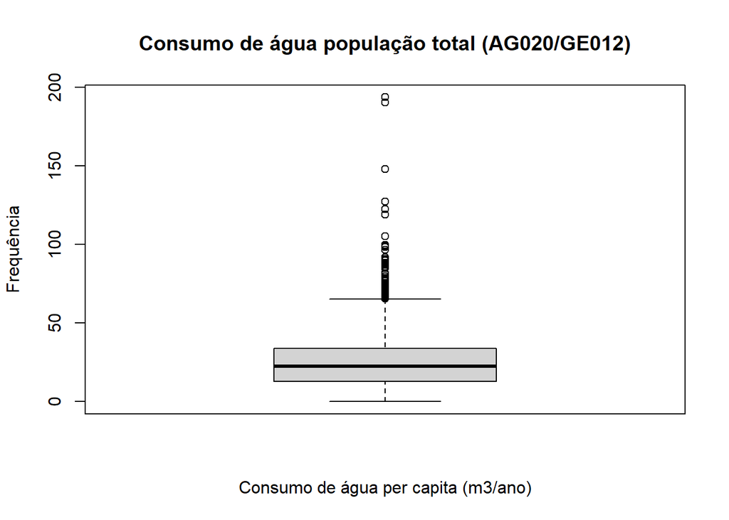

```r
boxplot(
  water_data$CONSUMO1,
  main = "Consumo de água população total (AG020/GE012)",
  xlab = "Consumo de água per capita (m3/ano)",
  ylab = "Frequência"
)
```

O box-plot de `CONSUMO1` indica que existem diversos valores atípicos (*outliers*), ou seja, fora dos limites.

#### Histograma

Um histograma é um tipo de gráfico utilizado para representar a distribuição de frequência da ocorrência de uma observação em um conjunto de dados.

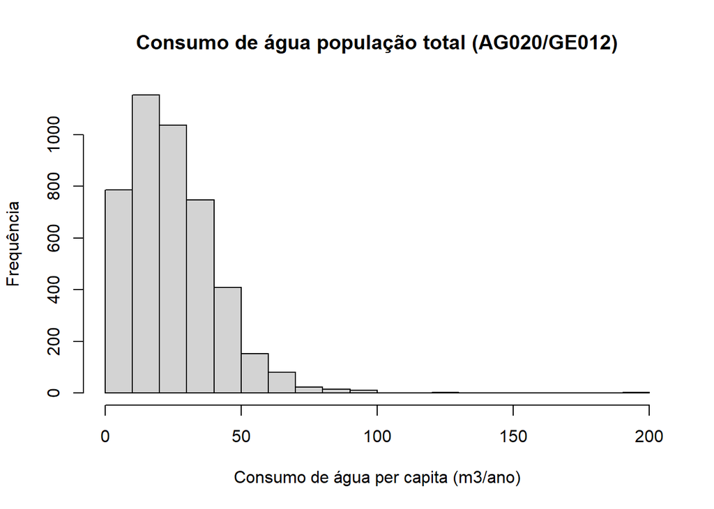

```r
hist(
  water_data$CONSUMO1,
  main = "Consumo de água população total (AG020/GE012)",
  xlab = "Consumo de água per capita (m3/ano)",
  ylab = "Frequência"
)
```

O histograma de `CONSUMO1` sugere uma distribuição positivamente assimétrica dessa variável. A barra maior indica a `moda`, que neste caso está entre 10-20 m3/ano, sendo menor do que a `média` (24,77 m3/ano) e `mediana` (22,35 m3/ano). Como a média, mediana e moda não coincidem, a distribuição de `CONSUMO1` não representa uma curva normal.

#### Qqplot

qqplot é um gráfico usado para avaliar se um conjunto de dados segue ou não um tipo de distribuição, como por exemplo, a distribuição normal.

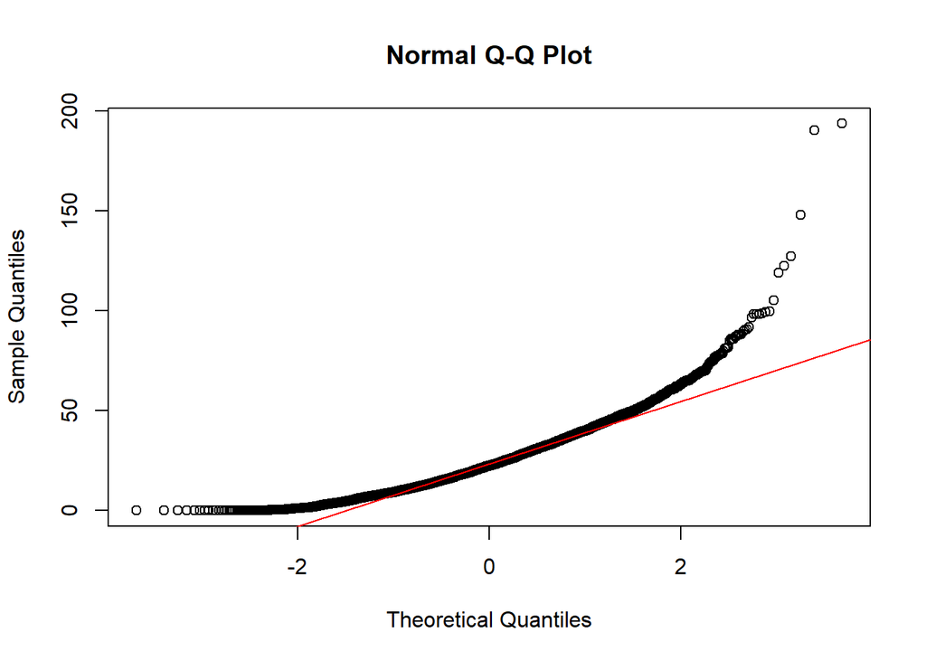

```r
qqnorm(water_data$CONSUMO1)
qqline(water_data$CONSUMO1, col = "red")
```

O qqplot de `CONSUMO1` sugere uma certa linearidade pela proximidade com a curva normal (em vermelho) nos quantis centrais, desviando da curva em valores muito altos e muito baixos (*outliers*).

### Exportando a base de dados

Após executar a rotina, você fez alterações na base de dados (novas variáveis - CONSUMO1 e CONSUMO2), por isso é importante salvá-la para acesso futuro. O R não vai exportar a sua base de dados a menos que você especifique esse comando.

```r
output_file_path <- "water_data_v2.csv"
write.csv2(water_data, output_file_path, row.names = FALSE)
```

** Essa aula foi baseada em: https://github.com/luisfelipebr/mti2020/blob/master/roteiros/roteiro2.Rmd. E os arquivos gerados podem ser visualizados em: https://github.com/jeniferss/ESHT011-21_ADPPT/tree/main/semana_02